# Bryan_DAmico_HW3

2022-10-23

## Introduction

Children oftentimes grow up hearing from adults how they should invest their money to start saving for their retirement as soon as they can. However, not everyone acts on this advice as they get older and start their careers. Financial institutions offer investment plans like PEPs, or personal equity plans, to their customers, but many still do not have these types of accounts. This may be because people do not know how to invest their money or that they’re worried they will just lose their money. Also, in the current economic climate, there are many people who are unable to invest even if they wanted to, because they are living paycheck to paycheck.

In recent years, there has been massive growth in the popularity of targeted advertising. One can hardly visit a website without seeing an ad related to something they purchased on Amazon or for a clothing brand from a website they recently browsed through. Targeted advertising saves companies money because they are only buying enough advertising space to ensure their intended audience sees it. This type of strategic advertising reduces marketing expenditures while attempting to maximize the return on investment from those advertisements.

The key to promoting personal equity plans using targeted advertising is understanding what type of customer will be interested in making that investment. If a financial institution is able to uncover the characteristics of the different types of people who currently have PEPs within their existing customer base, they will then be able to predict who is most likely to want to become a new customer and have a PEP. Data scientists have been able to quantify the relationship between a customer’s characteristics and a desired outcome through a data mining method known as association rule mining. This advancement in the world of analytics puts companies in a very advantageous position, where they are able to leverage the data they have been keeping for years in new and exciting ways.

## Analysis and Models

### About the Data

First, the required packages for the data analysis are loaded into R. These will allow for specific techniques used to manipulate and visualize the data, as well as create the association rule mining models.

```r
#Load in required packages
library(tidyverse)
library(arules)
library(arulesViz)
library(knitr)
```

The data set used for the analysis will now be loaded into R. This data set was provided by DePaul University and contains information from the marketing department of a financial institution. This data contains records of the demographic and account information of existing customers. The data consists of 600 customer records with 12 attributes recorded for each customer. The following table lists each of the 12 attributes as well as a description of each.

Description of the Bank Data Variables

| Attributes | Descriptions |
| --- | --- |
| id | A unique identification number |
| age | Age of customer in years |
| sex | Male/Female |
| region | Inner city/rural/suburban/town |
| income | Income of the customer |
| married | Is the customer married? (Yes/No) |
| children | Number of children |
| car | Does the customer own a car? (Yes/No) |
| save_act | Does the customer have a savings account? (Yes/No) |
| current_act | Does the customer have a current account? (Yes/No) |
| mortgage | Does the customer have a mortgage? (Yes/No) |
| pep | Did the customer buy a PEP after the last mailing? (Yes/No) |

The data is saved as a data frame, which is a two dimensional representation of the data, like a table. While reading in the data, any blank data points will be replaced by “NA” so they are easier to identify while cleaning the data.

```r
#Read in the data set and replace blank spaces with NA
bankdf <- read_csv("~/Documents/Syracuse/Quarter 2/Applied Machine Learning/Data Sets and Tutorials/Week 3/bankdata_csv_all.csv",
                   na = c(" ", "NA"))
```

Before performing the analysis, the structure of the data frame must be investigated to see what data types the different variables were read in as.

```r
#Check the structure of the data to see what data types the variables were imported as.
str(bankdf)
```

```
## spec_tbl_df [600 × 12] (S3: spec_tbl_df/tbl_df/tbl/data.frame)
##  $ id         : chr [1:600] "ID12101" "ID12102" "ID12103" "ID12104" ...
##  $ age        : num [1:600] 48 40 51 23 57 57 22 58 37 54 ...
##  $ sex        : chr [1:600] "FEMALE" "MALE" "FEMALE" "FEMALE" ...
##  $ region     : chr [1:600] "INNER_CITY" "TOWN" "INNER_CITY" "TOWN" ...
##  $ income     : num [1:600] 17546 30085 16575 20375 50576 ...
##  $ married    : chr [1:600] "NO" "YES" "YES" "YES" ...
##  $ children   : num [1:600] 1 3 0 3 0 2 0 0 2 2 ...
##  $ car        : chr [1:600] "NO" "YES" "YES" "NO" ...
##  $ save_act   : chr [1:600] "NO" "NO" "YES" "NO" ...
##  $ current_act: chr [1:600] "NO" "YES" "YES" "YES" ...
##  $ mortgage   : chr [1:600] "NO" "YES" "NO" "NO" ...
##  $ pep        : chr [1:600] "YES" "NO" "NO" "NO" ...
##  - attr(*, "spec")=
##   .. cols(
##   ..   id = col_character(),
##   ..   age = col_double(),
##   ..   sex = col_character(),
##   ..   region = col_character(),
##   ..   income = col_double(),
##   ..   married = col_character(),
##   ..   children = col_double(),
##   ..   car = col_character(),
##   ..   save_act = col_character(),
##   ..   current_act = col_character(),
##   ..   mortgage = col_character(),
##   ..   pep = col_character()
##   .. )
##  - attr(*, "problems")=<externalptr>
```

Unfortunately, many of these variables are not the correct data type required for the analysis. Since the id variable is just a row identifier, it is not useful for the analysis and will be removed.

```r
#id variable should be removed because it will not be used for ARM
bankdf <- bankdf %>%
  select(-id)
```

Before changing the data types of the rest of the variables, it is important to see if there are any missing values. If there are missing values they will need to be addressed in a manner that is appropriate depending on which variable they occur in.

```r
#Check to see if there are any missing values.
#Display any rows with missing values.
bankdf[rowSums(is.na(bankdf)) > 0,]
```

```
## # A tibble: 0 × 11
## # … with 11 variables: age <dbl>, sex <chr>, region <chr>, income <dbl>,
## #   married <chr>, children <dbl>, car <chr>, save_act <chr>,
## #   current_act <chr>, mortgage <chr>, pep <chr>
```

```r
#No rows so no missing data.
(sum(is.na(bankdf)))
```

```
## [1] 0
```

```r
#Sum is zero so there are no missing values.
```

There are no missing values, so now all of the data types can be changed without any worries.

All of the variables that are currently character strings: sex, region, married, car, save_act, current_act, mortgage, and pep need to be converted to nominal factors.

```r
#For ARM data needs to be discretized and converted to nominal factors start by converting the character variables to factor variables
bankdf$sex <- as.factor(bankdf$sex)
bankdf$region <- as.factor(bankdf$region)
bankdf$married <- as.factor(bankdf$married)
bankdf$car <- as.factor(bankdf$car)
bankdf$save_act <- as.factor(bankdf$save_act)
bankdf$current_act <- as.factor(bankdf$current_act)
bankdf$mortgage <- as.factor(bankdf$mortgage)
bankdf$pep <- as.factor(bankdf$pep)

#Check if data type conversion was successful
str(bankdf)
```

```
## tibble [600 × 11] (S3: tbl_df/tbl/data.frame)
##  $ age        : num [1:600] 48 40 51 23 57 57 22 58 37 54 ...
##  $ sex        : Factor w/ 2 levels "FEMALE","MALE": 1 2 1 1 1 1 2 2 1 2 ...
##  $ region     : Factor w/ 4 levels "INNER_CITY","RURAL",..: 1 4 1 4 2 4 2 4 3 4 ...
##  $ income     : num [1:600] 17546 30085 16575 20375 50576 ...
##  $ married    : Factor w/ 2 levels "NO","YES": 1 2 2 2 2 2 1 2 2 2 ...
##  $ children   : num [1:600] 1 3 0 3 0 2 0 0 2 2 ...
##  $ car        : Factor w/ 2 levels "NO","YES": 1 2 2 1 1 1 1 2 2 2 ...
##  $ save_act   : Factor w/ 2 levels "NO","YES": 1 1 2 1 2 2 1 2 1 2 ...
##  $ current_act: Factor w/ 2 levels "NO","YES": 1 2 2 2 1 2 2 2 1 2 ...
##  $ mortgage   : Factor w/ 2 levels "NO","YES": 1 2 1 1 1 1 1 1 1 1 ...
##  $ pep        : Factor w/ 2 levels "NO","YES": 2 1 1 1 1 2 2 1 1 1 ...
```

The variables which previously contained character strings are now nominal factor variables. Next, the variables that are currently of the integer type: age, income, and children need to be discretized. This is the process of turning continuous data into discrete data by grouping the values into ranges called bins. The bins can then be treated as factors. For example, if all customers aged 20-29 are placed into a bin then they are treated as all having the same age characteristic of being “in their twenties”.

The five number summary for the age variable provides information on how to create the bins for the descretization.

```r
#Take a look at the 5 number summary to decide on bins for the descretization
summary(bankdf$age)
```

```
##    Min. 1st Qu.  Median    Mean 3rd Qu.    Max.
##   18.00   30.00   42.00   42.40   55.25   67.00
```

Since the minimum age is 18 and the maximum age is 67, the age data can be binned by decades. The first bin will be for teenagers, the second for customers in their twenties, the third for customers in their thirties, and so on. The final bin will be for customers in their sixties, since there is no data that extends beyond that bin. Note that the lower bound for the first bin is 0 and the upper bound for the final bin is 120. This way if additional data is added to the data set, it will automatically be placed in the appropriate bin without having to rewrite the code. To reflect this, the final bin is labeled as being for customers who are sixty or older. In the code, the parameter “right” is set equal to false so that the right bound is included in the next bin. This means that someone who is exactly age 20 will be included in the “Twenties” bin and not the “Teenagers” bin.

```r
#Discretize the age variable. Set right = FALSE so that the right bound is included in the next bin instead of the previous.
bankdf$age <- cut(bankdf$age, breaks = c(0, 20, 30, 40, 50, 60, 120),
                  labels = c("Teenagers", "Twenties", "Thirties", "Forties",
                             "Fifties", "Sixty or Older"), right = FALSE)
```

Next is the income variable. The five number summary is again provided for the purpose of deciding on bins.

```r
#Take a look at the 5 number summary to decide on bins for the descretization
summary(bankdf$income)
```

```
##    Min. 1st Qu.  Median    Mean 3rd Qu.    Max.
##    5014   17264   24925   27524   36173   63130
```

The income data will be broken up into bins spanning intervals of $10,000. The first and last bins will not have a width of 10,000 to again accommodate any new data that is added. Since the minimum income is $5000, the first bin is set to span 0 to 15,000 while still having an effective width of 10,000 for the current data.

```r
#Descretize the income variable by binning the different income values.
bankdf$income <- cut(bankdf$income, breaks = c(0, 15000, 25000, 35000, 45000,
                                               55000, Inf),
                     labels = c("0-14999", "15000-24999", "25000-34999",
                                "35000-44999",
                                "45000-54999", "55000+"), right = FALSE)
```

The last variable that must have its data type converted is children. This variable requires a different approach since it is already discrete data with values that have a natural ordering. Children is therefore converted to an ordered factor variable, meaning that having 1 child is regarded as having more than 0 children, but less than 2 children.

```r
#Convert children to an ordered factor.
bankdf$children <- ordered(bankdf$children)
```

The bank data has now been cleaned and all of the variables are now of the factor type, which is required for the analyses. This can be confirmed by viewing the structure of the data set again.

```r
#confirm all variables are now of the correct data type.
str(bankdf)
```

```
## tibble [600 × 11] (S3: tbl_df/tbl/data.frame)
##  $ age        : Factor w/ 6 levels "Teenagers","Twenties",..: 4 4 5 2 5 5 2 5 3 5 ...
##  $ sex        : Factor w/ 2 levels "FEMALE","MALE": 1 2 1 1 1 1 2 2 1 2 ...
##  $ region     : Factor w/ 4 levels "INNER_CITY","RURAL",..: 1 4 1 4 2 4 2 4 3 4 ...
##  $ income     : Factor w/ 6 levels "0-14999","15000-24999",..: 2 3 2 2 5 4 1 2 3 2 ...
##  $ married    : Factor w/ 2 levels "NO","YES": 1 2 2 2 2 2 1 2 2 2 ...
##  $ children   : Ord.factor w/ 4 levels "0"<"1"<"2"<"3": 2 4 1 4 1 3 1 1 3 3 ...
##  $ car        : Factor w/ 2 levels "NO","YES": 1 2 2 1 1 1 1 2 2 2 ...
##  $ save_act   : Factor w/ 2 levels "NO","YES": 1 1 2 1 2 2 1 2 1 2 ...
##  $ current_act: Factor w/ 2 levels "NO","YES": 1 2 2 2 1 2 2 2 1 2 ...
##  $ mortgage   : Factor w/ 2 levels "NO","YES": 1 2 1 1 1 1 1 1 1 1 ...
##  $ pep        : Factor w/ 2 levels "NO","YES": 2 1 1 1 1 2 2 1 1 1 ...
```

Now each of the variables can be explored and visualized to get a better sense of the bank data before performing any analyses.

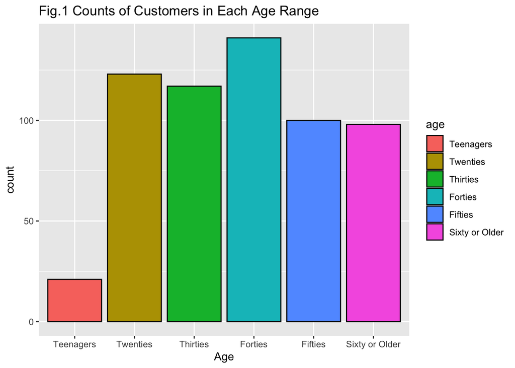

```r
#Visualize the distribution of the age variable.
bankdf %>%
  ggplot(aes(x = age, fill = age)) +
  geom_bar(color = "black") +
  labs(x = "Age") +
  ggtitle("Fig.1 Counts of Customers in Each Age Range")
```

It is clear from Figure 1 that an extreme minority of customers are teenagers. Otherwise, each of the age ranges are represented fairly equally, although there are more customers in each of the age ranges from twenties to forties than there are in the fifties or sixty or older age ranges. Also, the largest proportion of customers are in their forties.

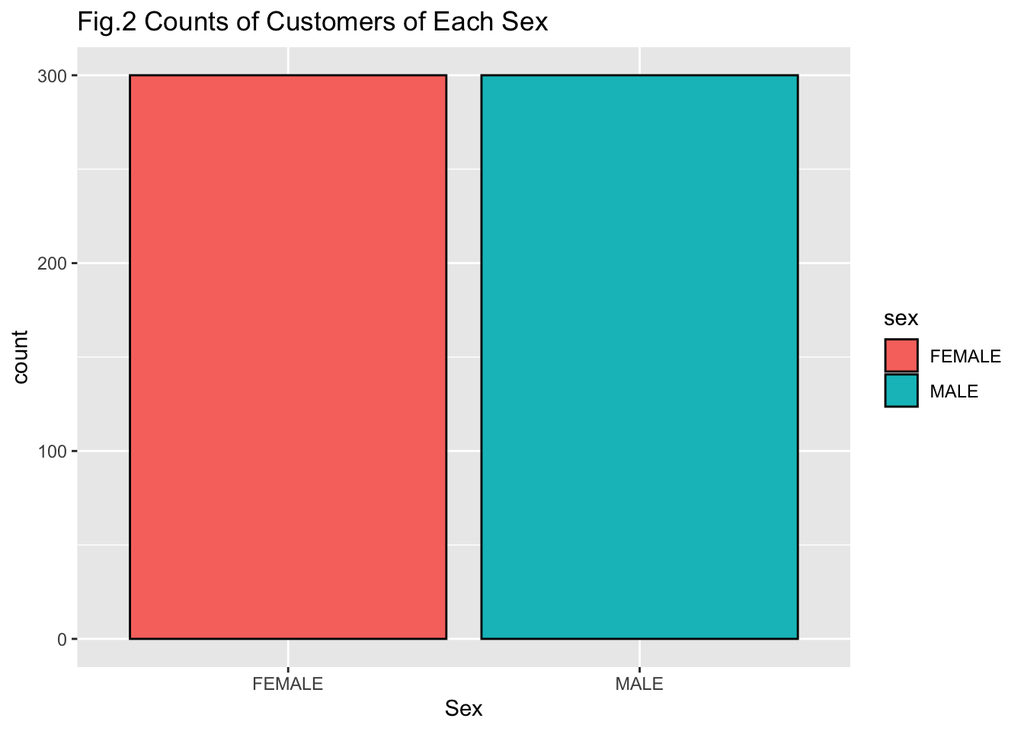

```r
#Visualize the distribution of the sex variable.
bankdf %>%
  ggplot(aes(x = sex, fill = sex)) +
  geom_bar(color = "black") +
  labs(x = "Sex") +
  ggtitle("Fig.2 Counts of Customers of Each Sex")
```

Figure 2 shows that the customers recorded in the bank data are split perfectly evenly by sex. Three hundred of the customers are female and three hundred are male. Having a uniform distribution will be helpful for the analyses. If too much of the data was skewed towards one sex or the other, it would be difficult to get a good understanding of any patterns that may occur in customers of the underrepresented sex.

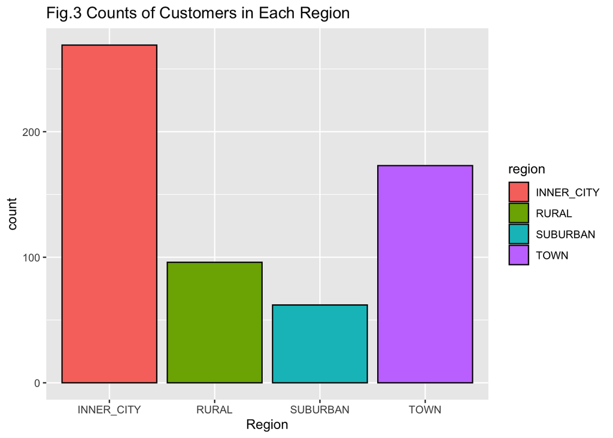

```r
#Visualize the distribution of the region variable.
bankdf %>%
  ggplot(aes(x = region, fill = region)) +
  geom_bar(color = "black") +
  labs(x = "Region") +
  ggtitle("Fig.3 Counts of Customers in Each Region")
```

The number of customers living in each region differs greatly from one another. The greatest proportion of customers live in the inner city, while very few of the customers live in rural or suburban regions.

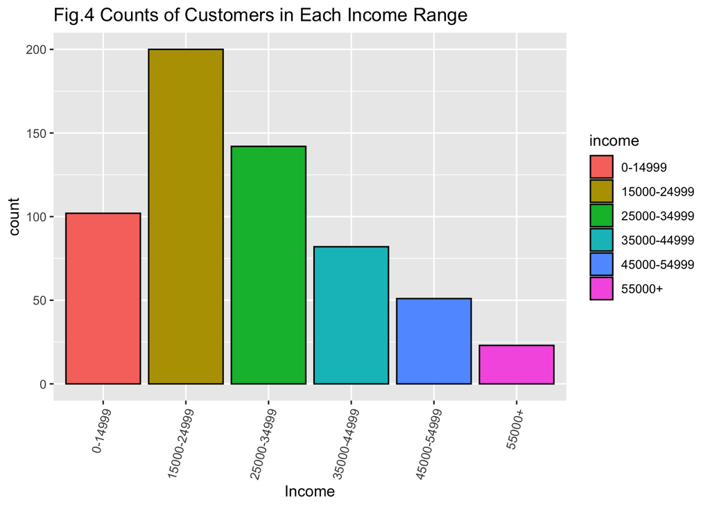

```r
#Visualize the distribution of the income variable.
bankdf %>%
  ggplot(aes(x = income, fill = income)) +
  geom_bar(color = "black") +
  labs(x = "Income") +
  ggtitle("Fig.4 Counts of Customers in Each Income Range") +
  theme(axis.text.x = element_text(angle = 75, vjust = 1, hjust = 1))
```

This bank data contains mostly customers belonging to a low income range. The smallest proportion of customers make $55,000 or more, while the greatest proportion of customers only make between $15,000 and $24,999. This means that the bank data will only allow for patterns to be uncovered regarding customers with low incomes, as there is not any available data on people with very high incomes.

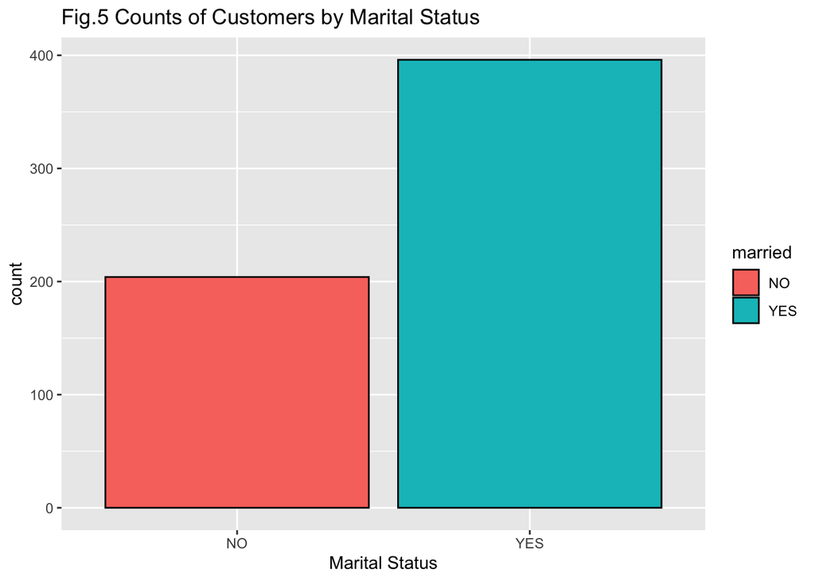

```r
#Visualize the distribution of the married variable.
bankdf %>%
  ggplot(aes(x = married, fill = married)) +
  geom_bar(color = "black") +
  labs(x = "Marital Status") +
  ggtitle("Fig.5 Counts of Customers by Marital Status")
```

Figure 5 makes it clear that the majority of the customers in the bank data are married. In fact 2/3 of the customers are married, while 1/3 of the customers are unmarried.

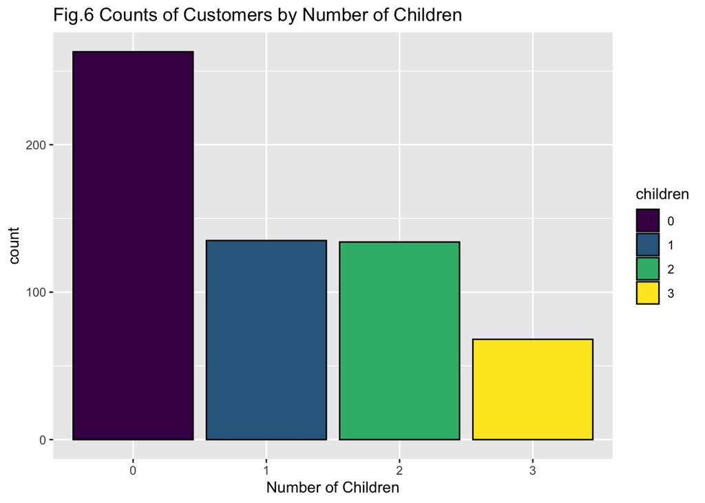

```r
#Visualize the distribution of the children variable.
bankdf %>%
  ggplot(aes(x = children, fill = children)) +
  geom_bar(color = "black") +
  labs(x = "Number of Children") +
  ggtitle("Fig.6 Counts of Customers by Number of Children")
```

A slight majority of the customers have some number of children versus having no children, although the “no children” category contains the greatest proportion of customers out of the four categories.

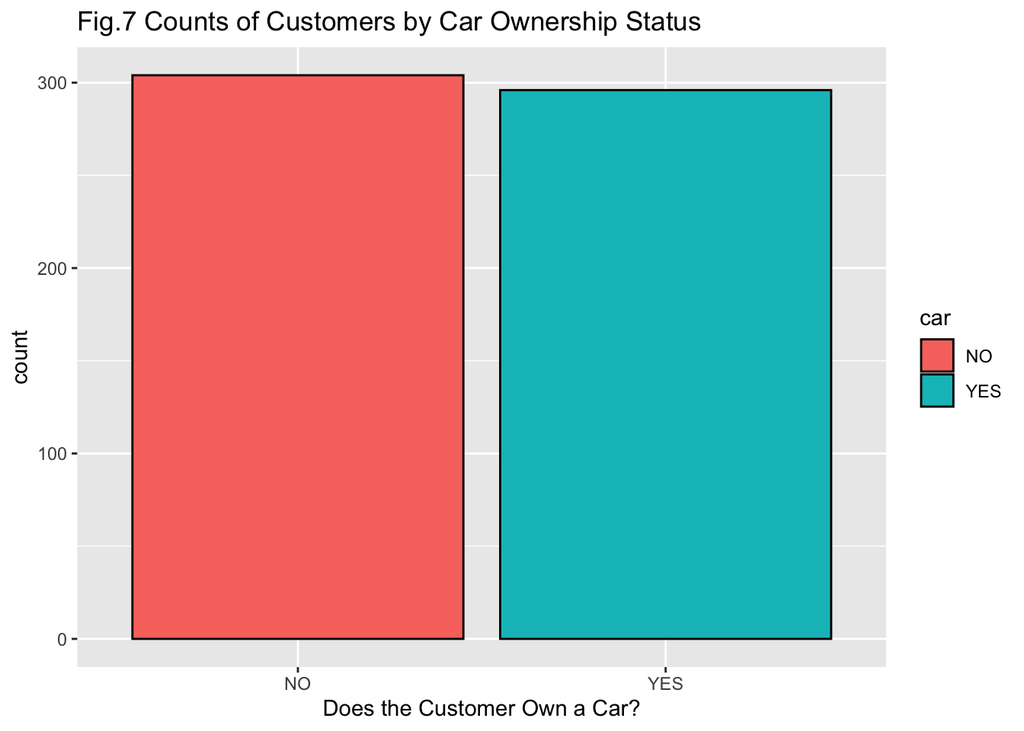

```r
#Visualize the distribution of the car variable.
bankdf %>%
  ggplot(aes(x = car, fill = car)) +
  geom_bar(color = "black") +
  labs(x = "Does the Customer Own a Car?") +
  ggtitle("Fig.7 Counts of Customers by Car Ownership Status")
```

Car ownership status is very close to equal among the customers in the bank data. Only a few more of the customers do not own a car compared to those who do own a car.

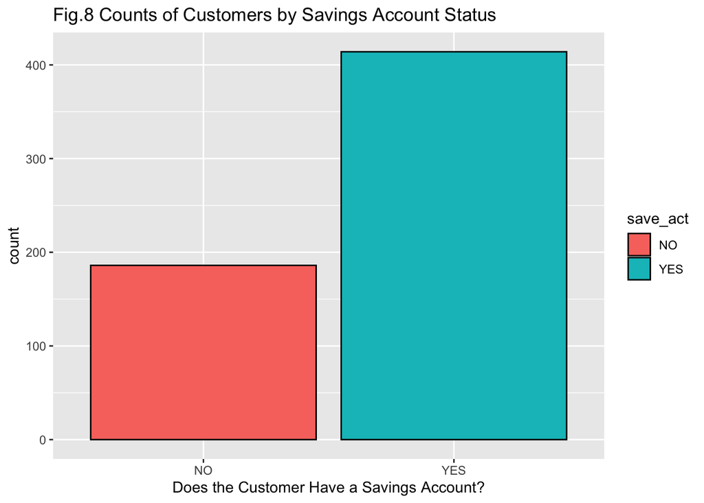

```r
#Visualize the distribution of the save_act variable.
bankdf %>%
  ggplot(aes(x = save_act, fill = save_act)) +
  geom_bar(color = "black") +
  labs(x = "Does the Customer Have a Savings Account?") +
  ggtitle("Fig.8 Counts of Customers by Savings Account Status")
```

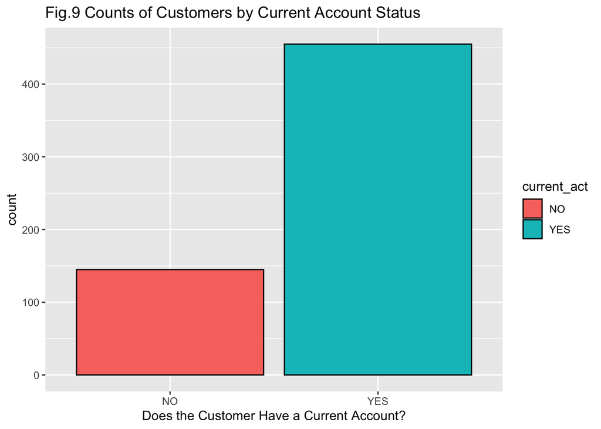

```r
#Visualize the distribution of the current_act variable.
bankdf %>%
  ggplot(aes(x = current_act, fill = current_act)) +
  geom_bar(color = "black") +
  labs(x = "Does the Customer Have a Current Account?") +
  ggtitle("Fig.9 Counts of Customers by Current Account Status")
```

Approximately 75% of the customers have a current account. For clarity, this does not mean that 75% of customers currently have some form of account with the bank. Current accounts are interest-free accounts that require a minimum balance, but have no limit to the number of transactions each day. This makes them ideal for people who run a small business and who will be triggering a banking transaction every time they make a sale.

(reference: https://www.hdfcbank.com/personal/resources/learning-centre/save/types-of-current-account)

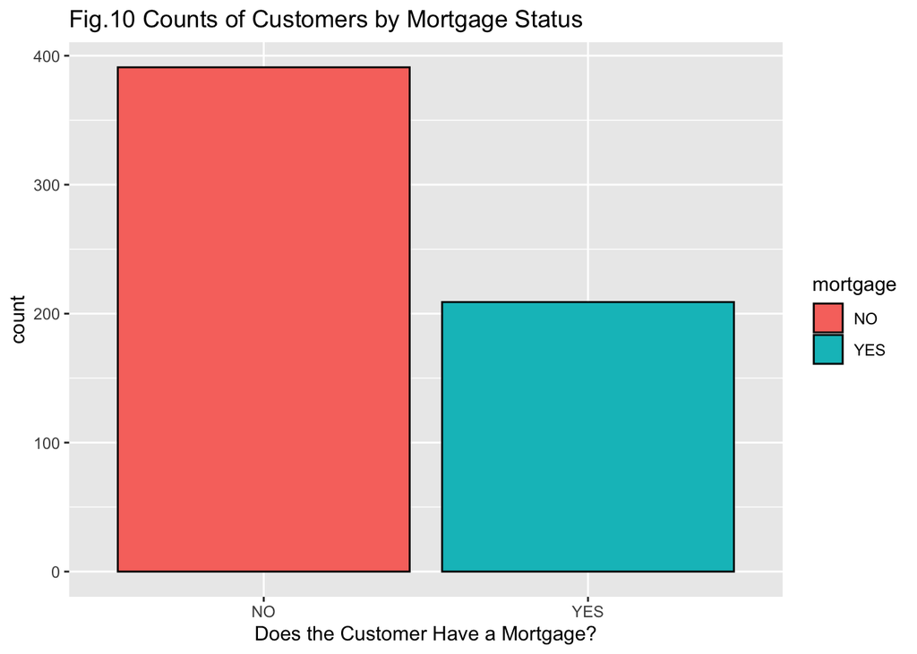

```r
#Visualize the distribution of the mortgage variable.
bankdf %>%
  ggplot(aes(x = mortgage, fill = mortgage)) +
  geom_bar(color = "black") +
  labs(x = "Does the Customer Have a Mortgage?") +
  ggtitle("Fig.10 Counts of Customers by Mortgage Status")
```

The majority of customers do not have a mortgage. This data is split such that only about one third of the customers do have a mortgage. Unfortunately, the bank data does not provide any information on a customer’s type of housing so it is impossible to say why a customer does not have a mortgage. It could be that they are renting or that their house is completely paid for.

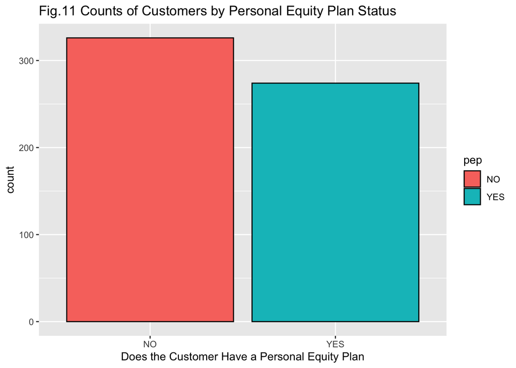

```r
#Visualize the distribution of the pep variable.
bankdf %>%
  ggplot(aes(x = pep, fill = pep)) +
  geom_bar(color = "black") +
  labs(x = "Does the Customer Have a Personal Equity Plan") +
  ggtitle("Fig.11 Counts of Customers by Personal Equity Plan Status")
```

The final visualization shows the proportions of customers who do or not currently have a personal equity plan. Just over half of the customers do not have a PEP. This variable is very important for the analyses, since the goal is to understand which of the customers’ characteristics lead to them having a PEP.

One final step is required to prepare the bank data for the analyses. The data set must be converted from a data frame to transaction data.

```r
#Prepare data for Association Rule Mining.
bankTransaction <- transactions(bankdf, format = "wide")

#View the structure of the transaction data.
str(bankTransaction)
```

```
## Formal class 'transactions' [package "arules"] with 3 slots
##   ..@ data       :Formal class 'ngCMatrix' [package "Matrix"] with 5 slots
##   .. .. ..@ i       : int [1:6600] 3 6 8 13 18 21 24 26 28 30 ...
##   .. .. ..@ p       : int [1:601] 0 11 22 33 44 55 66 77 88 99 ...
##   .. .. ..@ Dim     : int [1:2] 34 600
##   .. .. ..@ Dimnames:List of 2
##   .. .. .. ..$ : NULL
##   .. .. .. ..$ : NULL
##   .. .. ..@ factors : list()
##   ..@ itemInfo   :'data.frame':  34 obs. of  3 variables:
##   .. ..$ labels   : chr [1:34] "age=Teenagers" "age=Twenties" "age=Thirties" "age=Forties" ...
##   .. ..$ variables: Factor w/ 11 levels "age","car","children",..: 1 1 1 1 1 1 11 11 9 9 ...
##   .. ..$ levels   : Factor w/ 24 levels "0","0-14999",..: 20 23 21 13 12 18 11 15 14 17 ...
##   ..@ itemsetInfo:'data.frame':  600 obs. of  1 variable:
##   .. ..$ transactionID: chr [1:600] "1" "2" "3" "4" ...
```

The bank data is now fully ready for analysis.

### Analysis and Models

The goal of the analysis is to use association rule mining to build profiles of customers who would be interested in obtaining the new personal equity plan. The customer profiles will inform the marketing department about who to target and with what form of advertisement.

Association rule mining takes an algorithmic approach to frequent pattern analysis. It will find rules in a set of transactions that predict the occurrence of an attribute. In this case, the characteristics of a customer’s profile will be linked to other attributes those customers are likely to have.

Association rules are described in terms of itemsets. Each itemset is a collection of one or more items from the transaction data. In this case, each of the items is a customer attribute. Rules are primarily rated on three metrics: support, confidence, and lift.

Support describes the frequency of the itemset in the data. A support of 0.10 means that the items occur in 10% of all the itemsets. Confidence describes how often items appear together. A confidence of 0.90 means that there’s a 90% probability that items appear together given that one of the items appears. Lift describes how interesting the generated association rule is. Rules with a lift value of 1 describe itemsets where the appearance of one item does not affect the appearance of another item. Rules with a lift value greater than 1 describe itemsets where the appearance of one item increases the odds of the appearance of another item, but these pairs may not occur very often. Rules with a lift value less than 1 describe itemsets where each of the items occur very often, but almost never occur together.

Figure 12 displays the 20 most frequent items in the bank data. The first column, current_act=YES, reveals that this characteristic occurs in well more than 400 of the customer profiles.

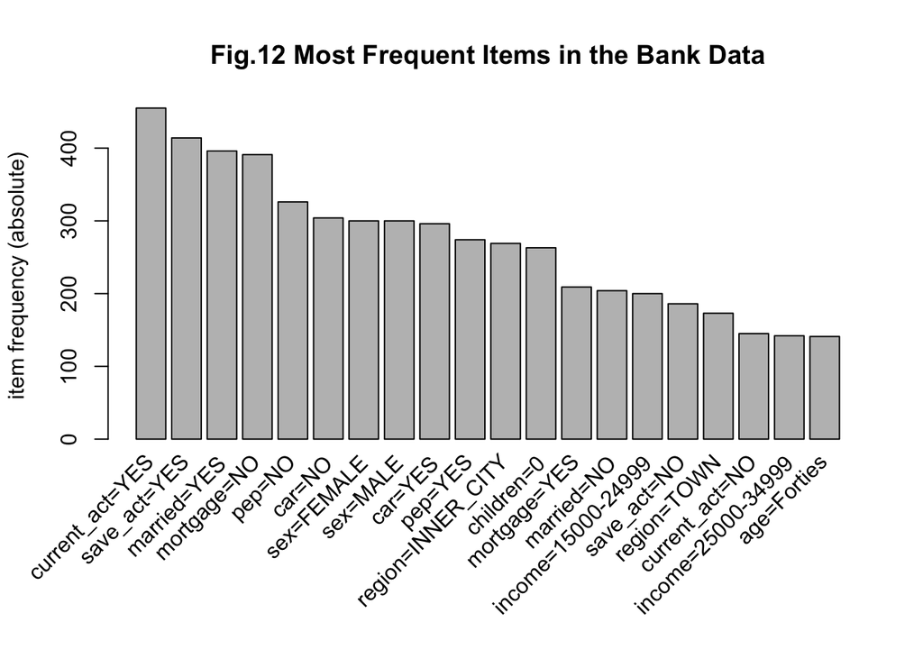

```r
#Take a look at the frequencies of the top 20 most frequent items to see which items are most likely to appear in mined association rules.
itemFrequencyPlot(bankTransaction, topN=20, type="absolute")
title("Fig.12 Most Frequent Items in the Bank Data")
```

The most frequently occurring items in the bank data would be the most likely to occur frequently in any mined association rules. These rules involving these most frequent items will likely reveal patterns in the data, however it may also be useful to look at rules involving items that do not occur frequently if they have strong confidence and lift. These rules may generate the most interesting results.

The first steps of the analysis will focus on generating interesting rules to better understand the customer data. The goal is to generate between 20 and 30 strong rules that feature high lift and confidence while still featuring good support. In general circumstances, a support value of 0.3 is considered to be quite strong. The first mining starts at that level without yet setting a level of confidence just to see if any rules are generated.

```r
#Generate rule set using the apriori algorithm
bankRules <- apriori(bankTransaction, parameter = list(supp = 0.30))
```

```
## Apriori
##
## Parameter specification:
##  confidence minval smax arem  aval originalSupport maxtime support minlen
##         0.8    0.1    1 none FALSE            TRUE       5     0.3      1
##  maxlen target  ext
##      10  rules TRUE
##
## Algorithmic control:
##  filter tree heap memopt load sort verbose
##     0.1 TRUE TRUE  FALSE TRUE    2    TRUE
##
## Absolute minimum support count: 180
##
## set item appearances ...[0 item(s)] done [0.00s].
## set transactions ...[34 item(s), 600 transaction(s)] done [0.00s].
## sorting and recoding items ... [16 item(s)] done [0.00s].
## creating transaction tree ... done [0.00s].
## checking subsets of size 1 2 3 4 done [0.00s].
## writing ... [0 rule(s)] done [0.00s].
## creating S4 object  ... done [0.00s].
```

```r
#Output summary of the rules to see how many, if any, were generated and to see the summary of the quality measures.
summary(bankRules)
```

```
## set of 0 rules
```

That level of support resulted in 0 rules so it was too high for this data. The support was lowered to 0.15 and the association rule mining algorithm was run again. This time it returned 19 rules without yet setting a confidence level. This number of rules is too few, but it is an improvement over the last run.

```r
bankRules <- apriori(bankTransaction, parameter = list(supp = 0.15))
```

```
## Apriori
##
## Parameter specification:
##  confidence minval smax arem  aval originalSupport maxtime support minlen
##         0.8    0.1    1 none FALSE            TRUE       5    0.15      1
##  maxlen target  ext
##      10  rules TRUE
##
## Algorithmic control:
##  filter tree heap memopt load sort verbose
##     0.1 TRUE TRUE  FALSE TRUE    2    TRUE
##
## Absolute minimum support count: 90
##
## set item appearances ...[0 item(s)] done [0.00s].
## set transactions ...[34 item(s), 600 transaction(s)] done [0.00s].
## sorting and recoding items ... [28 item(s)] done [0.00s].
## creating transaction tree ... done [0.00s].
## checking subsets of size 1 2 3 4 5 done [0.00s].
## writing ... [19 rule(s)] done [0.00s].
## creating S4 object  ... done [0.00s].
```

```r
summary(bankRules)
```

```
## set of 19 rules
##
## rule length distribution (lhs + rhs):sizes
##  2  3  4  5
##  1  6 11  1
##
##    Min. 1st Qu.  Median    Mean 3rd Qu.    Max.
##   2.000   3.000   4.000   3.632   4.000   5.000
##
## summary of quality measures:
##     support         confidence        coverage           lift
##  Min.   :0.1500   Min.   :0.8015   Min.   :0.1783   Min.   :1.057
##  1st Qu.:0.1733   1st Qu.:0.8088   1st Qu.:0.1958   1st Qu.:1.069
##  Median :0.1783   Median :0.8168   Median :0.2183   Median :1.238
##  Mean   :0.1900   Mean   :0.8348   Mean   :0.2284   Mean   :1.266
##  3rd Qu.:0.1942   3rd Qu.:0.8435   3rd Qu.:0.2325   3rd Qu.:1.280
##  Max.   :0.2850   Max.   :0.9720   Max.   :0.3483   Max.   :1.784
##      count
##  Min.   : 90.0
##  1st Qu.:104.0
##  Median :107.0
##  Mean   :114.0
##  3rd Qu.:116.5
##  Max.   :171.0
##
## mining info:
##             data ntransactions support confidence
##  bankTransaction           600    0.15        0.8
##                                                            call
##  apriori(data = bankTransaction, parameter = list(supp = 0.15))
```

Since a support level of 0.15 generated some rules, lowering it to 0.12 is guaranteed to find more. This means the desired threshold of 20 rules would be passed without any confidence parameter being set. So, at this point, the confidence parameter was also added to make sure that the rules that are being found have high confidence. Setting the confidence level to 0.9 means that any rules generated contain itemsets that are found together at least 90% of the time they are found at all.

```r
bankRules <- apriori(bankTransaction, parameter = list(supp = 0.12, conf = 0.9))
```

```
## Apriori
##
## Parameter specification:
##  confidence minval smax arem  aval originalSupport maxtime support minlen
##         0.9    0.1    1 none FALSE            TRUE       5    0.12      1
##  maxlen target  ext
##      10  rules TRUE
##
## Algorithmic control:
##  filter tree heap memopt load sort verbose
##     0.1 TRUE TRUE  FALSE TRUE    2    TRUE
##
## Absolute minimum support count: 72
##
## set item appearances ...[0 item(s)] done [0.00s].
## set transactions ...[34 item(s), 600 transaction(s)] done [0.00s].
## sorting and recoding items ... [29 item(s)] done [0.00s].
## creating transaction tree ... done [0.00s].
## checking subsets of size 1 2 3 4 5 done [0.00s].
## writing ... [6 rule(s)] done [0.00s].
## creating S4 object  ... done [0.00s].
```

```r
summary(bankRules)
```

```
## set of 6 rules
##
## rule length distribution (lhs + rhs):sizes
## 4 5
## 1 5
##
##    Min. 1st Qu.  Median    Mean 3rd Qu.    Max.
##   4.000   5.000   5.000   4.833   5.000   5.000
##
## summary of quality measures:
##     support         confidence        coverage           lift
##  Min.   :0.1217   Min.   :0.9091   Min.   :0.1233   Min.   :1.473
##  1st Qu.:0.1246   1st Qu.:0.9143   1st Qu.:0.1342   1st Qu.:1.482
##  Median :0.1333   Median :0.9458   Median :0.1408   Median :1.584
##  Mean   :0.1361   Mean   :0.9459   Mean   :0.1439   Mean   :1.582
##  3rd Qu.:0.1333   3rd Qu.:0.9747   3rd Qu.:0.1462   3rd Qu.:1.678
##  Max.   :0.1733   Max.   :0.9865   Max.   :0.1783   Max.   :1.692
##      count
##  Min.   : 73.00
##  1st Qu.: 74.75
##  Median : 80.00
##  Mean   : 81.67
##  3rd Qu.: 80.00
##  Max.   :104.00
##
## mining info:
##             data ntransactions support confidence
##  bankTransaction           600    0.12        0.9
##                                                                        call
##  apriori(data = bankTransaction, parameter = list(supp = 0.12, conf = 0.9))
```

Asking for such strict confidence filtered out too many of the previously found rules and the number of rules found was again reduced below the desired threshold. Since the goal is primarily to find rules with high confidence and lift, the confidence level will remain the same while the support threshold is lowered.

```r
bankRules <- apriori(bankTransaction, parameter = list(supp = 0.07, conf = 0.9))
```

```
## Apriori
##
## Parameter specification:
##  confidence minval smax arem  aval originalSupport maxtime support minlen
##         0.9    0.1    1 none FALSE            TRUE       5    0.07      1
##  maxlen target  ext
##      10  rules TRUE
##
## Algorithmic control:
##  filter tree heap memopt load sort verbose
##     0.1 TRUE TRUE  FALSE TRUE    2    TRUE
##
## Absolute minimum support count: 42
##
## set item appearances ...[0 item(s)] done [0.00s].
## set transactions ...[34 item(s), 600 transaction(s)] done [0.00s].
## sorting and recoding items ... [32 item(s)] done [0.00s].
## creating transaction tree ... done [0.00s].
## checking subsets of size 1 2 3 4 5 6 done [0.00s].
## writing ... [33 rule(s)] done [0.00s].
## creating S4 object  ... done [0.00s].
```

```r
summary(bankRules)
```

```
## set of 33 rules
##
## rule length distribution (lhs + rhs):sizes
##  2  3  4  5  6
##  1  1  4 16 11
##
##    Min. 1st Qu.  Median    Mean 3rd Qu.    Max.
##   2.000   5.000   5.000   5.061   6.000   6.000
##
## summary of quality measures:
##     support          confidence        coverage            lift
##  Min.   :0.07167   Min.   :0.9000   Min.   :0.07500   Min.   :1.364
##  1st Qu.:0.07333   1st Qu.:0.9149   1st Qu.:0.08000   1st Qu.:1.481
##  Median :0.08500   Median :0.9362   Median :0.08667   Median :1.656
##  Mean   :0.09303   Mean   :0.9424   Mean   :0.09874   Mean   :1.606
##  3rd Qu.:0.10000   3rd Qu.:0.9778   3rd Qu.:0.10667   3rd Qu.:1.687
##  Max.   :0.17333   Max.   :1.0000   Max.   :0.17833   Max.   :2.056
##      count
##  Min.   : 43.00
##  1st Qu.: 44.00
##  Median : 51.00
##  Mean   : 55.82
##  3rd Qu.: 60.00
##  Max.   :104.00
##
## mining info:
##             data ntransactions support confidence
##  bankTransaction           600    0.07        0.9
##                                                                        call
##  apriori(data = bankTransaction, parameter = list(supp = 0.07, conf = 0.9))
```

Reducing the support threshold by 0.05 increased the number of rules to 33. To reduce the total number of rules generated to between 20 and 30, the confidence level is increased slightly. This is an ideal situation because one of the main focuses of this rule mining is to find a set of rules with very high confidence.

```r
bankRules <- apriori(bankTransaction, parameter = list(supp = 0.07, conf = 0.91))
```

```
## Apriori
##
## Parameter specification:
##  confidence minval smax arem  aval originalSupport maxtime support minlen
##        0.91    0.1    1 none FALSE            TRUE       5    0.07      1
##  maxlen target  ext
##      10  rules TRUE
##
## Algorithmic control:
##  filter tree heap memopt load sort verbose
##     0.1 TRUE TRUE  FALSE TRUE    2    TRUE
##
## Absolute minimum support count: 42
##
## set item appearances ...[0 item(s)] done [0.00s].
## set transactions ...[34 item(s), 600 transaction(s)] done [0.00s].
## sorting and recoding items ... [32 item(s)] done [0.00s].
## creating transaction tree ... done [0.00s].
## checking subsets of size 1 2 3 4 5 6 done [0.00s].
## writing ... [26 rule(s)] done [0.00s].
## creating S4 object  ... done [0.00s].
```

```r
summary(bankRules)
```

```
## set of 26 rules
##
## rule length distribution (lhs + rhs):sizes
##  2  3  4  5  6
##  1  1  4 12  8
##
##    Min. 1st Qu.  Median    Mean 3rd Qu.    Max.
##   2.000   5.000   5.000   4.962   6.000   6.000
##
## summary of quality measures:
##     support          confidence        coverage            lift
##  Min.   :0.07167   Min.   :0.9125   Min.   :0.07500   Min.   :1.377
##  1st Qu.:0.07333   1st Qu.:0.9233   1st Qu.:0.07875   1st Qu.:1.479
##  Median :0.08417   Median :0.9528   Median :0.08500   Median :1.490
##  Mean   :0.09250   Mean   :0.9526   Mean   :0.09705   Mean   :1.601
##  3rd Qu.:0.09875   3rd Qu.:0.9785   3rd Qu.:0.10333   3rd Qu.:1.692
##  Max.   :0.17333   Max.   :1.0000   Max.   :0.17833   Max.   :2.056
##      count
##  Min.   : 43.00
##  1st Qu.: 44.00
##  Median : 50.50
##  Mean   : 55.50
##  3rd Qu.: 59.25
##  Max.   :104.00
##
## mining info:
##             data ntransactions support confidence
##  bankTransaction           600    0.07       0.91
##                                                                         call
##  apriori(data = bankTransaction, parameter = list(supp = 0.07, conf = 0.91))
```

After increasing the confidence by 0.01, a set of 26 rules was generated. Looking at the summary of quality measures provides some initial information about the rules. The median support is approximately 0.08 which means half of the itemsets the rules were created from occur in the overall data more than 8% of the time. Since there are 600 records in the bank data, even at 8%, these items are still occurring a fair number of times. Since the confidence level was set to 0.91, it is already known that all of the rules generated have strong confidence. The levels of lift are all in the range of what is usually considered strong, with at least one rule even exceeding a lift of 2.0. This means that the rules that have been generated do feature a positive correlation between their itemsets and some level of novelty.

Since all of the rules in this set have very high confidence, this rule set will be featured in the results section as a representative set of interesting rules regarding the customer profiles.

The second goal of the analysis is to uncover strong rules that imply that a certain customer profile will want to obtain a new personal equity plan based on the behavior of existing customers. When generating association rules, the right hand side of the rule can be set. In this case, it will be set to pep=YES, meaning that the customer has a personal equity plan. To start, the support and confidence levels will be kept the same compared to the previous association rule mining.

```r
bankRulesPEP <- apriori(data = bankTransaction, parameter = list(supp=0.07, conf =
                                                                   0.91),
                   appearance = list(default="lhs", rhs="pep=YES"),
                   control = list(verbose = F))
summary(bankRulesPEP)
```

```
## set of 3 rules
##
## rule length distribution (lhs + rhs):sizes
## 3 4 5
## 1 1 1
##
##    Min. 1st Qu.  Median    Mean 3rd Qu.    Max.
##     3.0     3.5     4.0     4.0     4.5     5.0
##
## summary of quality measures:
##     support          confidence        coverage            lift
##  Min.   :0.07333   Min.   :0.9167   Min.   :0.08000   Min.   :2.007
##  1st Qu.:0.07417   1st Qu.:0.9271   1st Qu.:0.08000   1st Qu.:2.030
##  Median :0.07500   Median :0.9375   Median :0.08000   Median :2.053
##  Mean   :0.07500   Mean   :0.9310   Mean   :0.08056   Mean   :2.039
##  3rd Qu.:0.07583   3rd Qu.:0.9381   3rd Qu.:0.08083   3rd Qu.:2.054
##  Max.   :0.07667   Max.   :0.9388   Max.   :0.08167   Max.   :2.056
##      count
##  Min.   :44.0
##  1st Qu.:44.5
##  Median :45.0
##  Mean   :45.0
##  3rd Qu.:45.5
##  Max.   :46.0
##
## mining info:
##             data ntransactions support confidence
##  bankTransaction           600    0.07       0.91
##                                                                                                                                                           call
##  apriori(data = bankTransaction, parameter = list(supp = 0.07, conf = 0.91), appearance = list(default = "lhs", rhs = "pep=YES"), control = list(verbose = F))
```

This only returned three rules. Since a specific right hand side is being targeted, the support values must be lowered to generate more results.

```r
bankRulesPEP <- apriori(data = bankTransaction, parameter = list(supp=0.04, conf =
                                                                   0.91),
                   appearance = list(default="lhs", rhs="pep=YES"),
                   control = list(verbose = F))
summary(bankRulesPEP)
```

```
## set of 24 rules
##
## rule length distribution (lhs + rhs):sizes
##  3  4  5  6
##  3 12  8  1
##
##    Min. 1st Qu.  Median    Mean 3rd Qu.    Max.
##   3.000   4.000   4.000   4.292   5.000   6.000
##
## summary of quality measures:
##     support          confidence        coverage            lift
##  Min.   :0.04000   Min.   :0.9167   Min.   :0.04000   Min.   :2.007
##  1st Qu.:0.04333   1st Qu.:0.9286   1st Qu.:0.04625   1st Qu.:2.033
##  Median :0.04667   Median :0.9474   Median :0.04750   Median :2.075
##  Mean   :0.05132   Mean   :0.9528   Mean   :0.05396   Mean   :2.086
##  3rd Qu.:0.05875   3rd Qu.:0.9663   3rd Qu.:0.06167   3rd Qu.:2.116
##  Max.   :0.07667   Max.   :1.0000   Max.   :0.08167   Max.   :2.190
##      count
##  Min.   :24.00
##  1st Qu.:26.00
##  Median :28.00
##  Mean   :30.79
##  3rd Qu.:35.25
##  Max.   :46.00
##
## mining info:
##             data ntransactions support confidence
##  bankTransaction           600    0.04       0.91
##                                                                                                                                                           call
##  apriori(data = bankTransaction, parameter = list(supp = 0.04, conf = 0.91), appearance = list(default = "lhs", rhs = "pep=YES"), control = list(verbose = F))
```

These parameters generate 24 rules, all of which have very strong lifts, ranging from about 2.0 to 2.2. In this instance, the low levels of support are not a concern because the goal of this rule mining is to find very interesting rules, not necessarily the strongest or most prevalent ones. The lift levels inspire confidence that this rule set will reveal interesting patterns in the customer profiles.

## Results

The general bank rules that were generated by the association rule mining algorithm with a minimum support level of 0.07 and minimum confidence level of 0.91 can be reordered to prioritize lift. The rules with the highest lifts will be those that are the most highly correlated among the set that has already met the requirements of being frequent and consistent.

```r
#The rules are sorted in decreasing order by lift so the highest lift rules of the set of high confidence rules will be displayed first.
bankRules <- sort(bankRules, decreasing = TRUE, by = "lift")
#The inspect function displays the first 5 rules in the newly ordered rule set.
inspect(bankRules[1:5])
```

```
##     lhs                      rhs          support confidence   coverage     lift count
## [1] {income=15000-24999,
##      children=1}          => {pep=YES} 0.07666667  0.9387755 0.08166667 2.055713    46
## [2] {married=NO,
##      children=0,
##      mortgage=NO}         => {pep=YES} 0.07500000  0.9375000 0.08000000 2.052920    45
## [3] {married=YES,
##      children=1,
##      save_act=YES,
##      current_act=YES}     => {pep=YES} 0.07333333  0.9166667 0.08000000 2.007299    44
## [4] {sex=FEMALE,
##      married=YES,
##      children=0,
##      save_act=YES,
##      current_act=YES}     => {pep=NO}  0.07333333  0.9361702 0.07833333 1.723013    44
## [5] {children=0,
##      save_act=YES,
##      current_act=YES,
##      mortgage=YES}        => {pep=NO}  0.07166667  0.9347826 0.07666667 1.720459    43
```

Interestingly, even without specifically asking for rules that will lead to a conclusion about PEP, those have been generated here. The metrics of support, confidence, and lift will be interpreted using the first rule as an example.

- A support of approximately 0.077 means that about 7.7% of all of the transactions feature itemsets that contain the items {income=15000-24999, children=1, pep=YES}.
- A confidence of approximately 0.94 means that about 94% of the time when {income=15000-24999, children=1} appears that {pep=YES} also appears.
- A lift of approximately 2.06 means that this particular itemset does not appear very often (as shown by having a support of 7.7%), but when the left hand side items do appear, they very frequently are seen together with the right hand side item (as shown by having a confidence of 0.94).

To summarize these facts: almost 94% of customers with an income between $15,000 and $24,999 who have one child have a personal equity plan.

However, since the initial exploration was intended to uncover different information about the data set that is not directly related to PEP, the rule set is reordered by confidence to see what else it contains.

```r
#This time the rules are sorted by confidence to see a different top 5.
bankRules <- sort(bankRules, decreasing = TRUE, by = "confidence")
#The inspect function displays the first 5 rules in the newly ordered rule set.
inspect(bankRules[1:5])
```

```
##     lhs                     rhs              support confidence   coverage     lift count
## [1] {income=45000-54999} => {save_act=YES} 0.0850000  1.0000000 0.08500000 1.449275    51
## [2] {children=0,
##      save_act=YES,
##      mortgage=NO,
##      pep=NO}             => {married=YES}  0.1216667  0.9864865 0.12333333 1.494676    73
## [3] {sex=FEMALE,
##      children=0,
##      mortgage=NO,
##      pep=NO}             => {married=YES}  0.1050000  0.9843750 0.10666667 1.491477    63
## [4] {children=0,
##      save_act=YES,
##      current_act=YES,
##      mortgage=NO,
##      pep=NO}             => {married=YES}  0.0950000  0.9827586 0.09666667 1.489028    57
## [5] {region=INNER_CITY,
##      children=0,
##      mortgage=NO,
##      pep=NO}             => {married=YES}  0.0850000  0.9807692 0.08666667 1.486014    51
```

This time some very interesting rules are revealed. Looking at rule 2, customers who have no children, do have a savings account, do not have a mortgage, and do not have a PEP have an almost 99% chance of being married. This is a surprising result, not only because does it link not having children with being married, but it also has quite a high support level of 0.12.

The entire set of association rules can also be visualized to see the greater picture all at once.

```
## To reduce overplotting, jitter is added! Use jitter = 0 to prevent jitter.
```

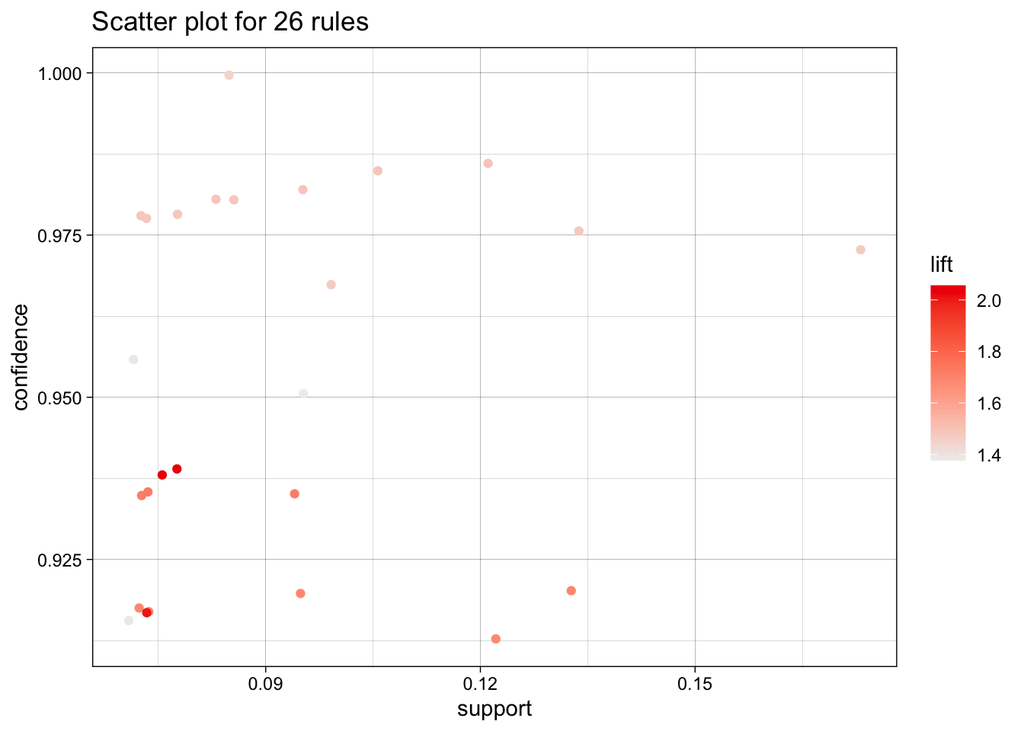

```r
plot(bankRules)
```

The darkest colored dots on the scatter plot represent the first set of rules revealed where the rule set was ordered by lift. These rules describe the customer profiles that ended up having or not having the PEP. The dots that are highest on the scatter plot represent the second set of rules which were ordered by confidence.

The rules can also be visualized directly in terms of how the items connect with one another to make itemsets and rules.

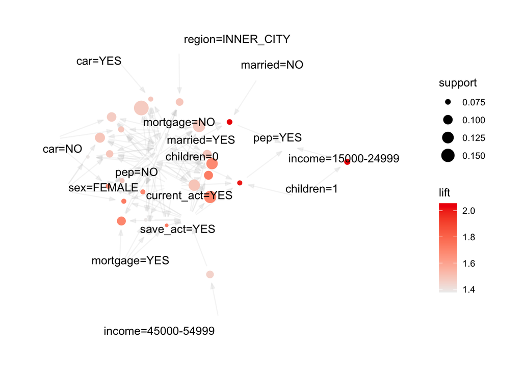

```r
plot(bankRules, method = "graph")
```

This visualization can be difficult to interpret when there are many items involved. However, outside of a report the visualization can be generated in an interactive manner which allows the user to space out all of the dots, which represent the rules, to see which items are joining to create the rule.

Now, a list of rules can also be generated where having a personal equity plan is always the right hand side. These rules will be sorted by lift and displayed in their entirety.

```r
#The rules with PEP as the RHS are sorted by lift.
bankRulesPEP <- sort(bankRulesPEP, decreasing = TRUE, by = "lift")
#The top 10 rules according to lift are displayed.
inspect(bankRulesPEP)
```

```
##      lhs                      rhs          support confidence   coverage     lift count
## [1]  {age=Forties,
##       children=1}          => {pep=YES} 0.06000000  1.0000000 0.06000000 2.189781    36
## [2]  {age=Forties,
##       children=1,
##       save_act=YES}        => {pep=YES} 0.04833333  1.0000000 0.04833333 2.189781    29
## [3]  {age=Forties,
##       children=1,
##       current_act=YES}     => {pep=YES} 0.04666667  1.0000000 0.04666667 2.189781    28
## [4]  {age=Forties,
##       children=1,
##       save_act=YES,
##       current_act=YES}     => {pep=YES} 0.04000000  1.0000000 0.04000000 2.189781    24
## [5]  {income=25000-34999,
##       children=1}          => {pep=YES} 0.05166667  0.9687500 0.05333333 2.121350    31
## [6]  {married=NO,
##       children=0,
##       save_act=YES,
##       mortgage=NO}         => {pep=YES} 0.05166667  0.9687500 0.05333333 2.121350    31
## [7]  {income=15000-24999,
##       children=1,
##       mortgage=NO}         => {pep=YES} 0.04666667  0.9655172 0.04833333 2.114271    28
## [8]  {income=15000-24999,
##       children=1,
##       save_act=YES}        => {pep=YES} 0.04500000  0.9642857 0.04666667 2.111575    27
## [9]  {income=15000-24999,
##       married=YES,
##       children=1,
##       current_act=YES}     => {pep=YES} 0.04500000  0.9642857 0.04666667 2.111575    27
## [10] {income=15000-24999,
##       children=1,
##       car=NO}              => {pep=YES} 0.04333333  0.9629630 0.04500000 2.108678    26
## [11] {married=NO,
##       children=0,
##       save_act=YES,
##       current_act=YES,
##       mortgage=NO}         => {pep=YES} 0.04166667  0.9615385 0.04333333 2.105559    25
## [12] {income=15000-24999,
##       married=YES,
##       children=1}          => {pep=YES} 0.06000000  0.9473684 0.06333333 2.074529    36
```

[output cut: 25 more lines]

```
##       mortgage=NO}         => {pep=YES} 0.04166667  0.9259259 0.04500000 2.027575    25
## [21] {sex=FEMALE,
##       income=15000-24999,
##       children=1}          => {pep=YES} 0.04000000  0.9230769 0.04333333 2.021336    24
## [22] {married=YES,
##       children=1,
##       car=NO,
##       save_act=YES}        => {pep=YES} 0.04000000  0.9230769 0.04333333 2.021336    24
## [23] {children=0,
##       save_act=NO,
##       mortgage=YES}        => {pep=YES} 0.05666667  0.9189189 0.06166667 2.012231    34
## [24] {married=YES,
##       children=1,
##       save_act=YES,
##       current_act=YES}     => {pep=YES} 0.07333333  0.9166667 0.08000000 2.007299    44
```

These rules targeting personal equity plans can also be visualized in the same way as the general rule set.

```
## To reduce overplotting, jitter is added! Use jitter = 0 to prevent jitter.
```

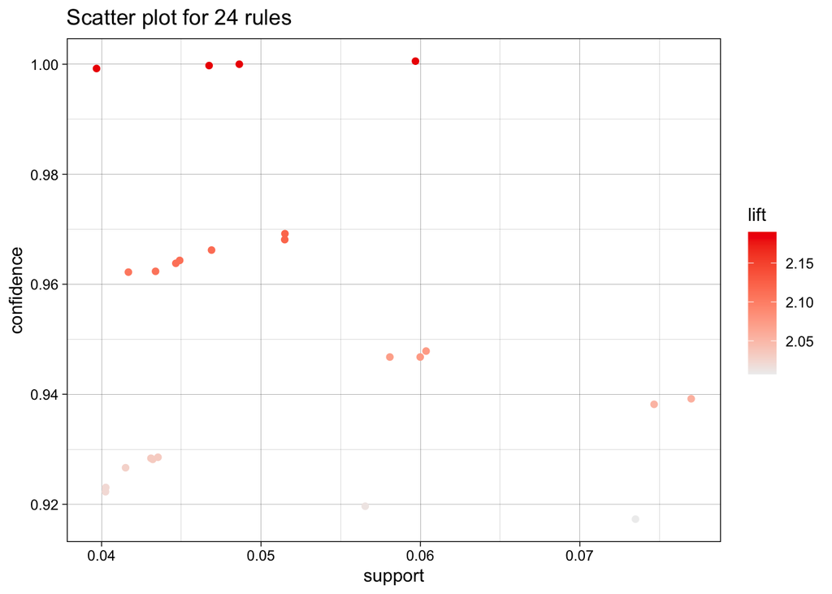

```r
plot(bankRulesPEP)
```

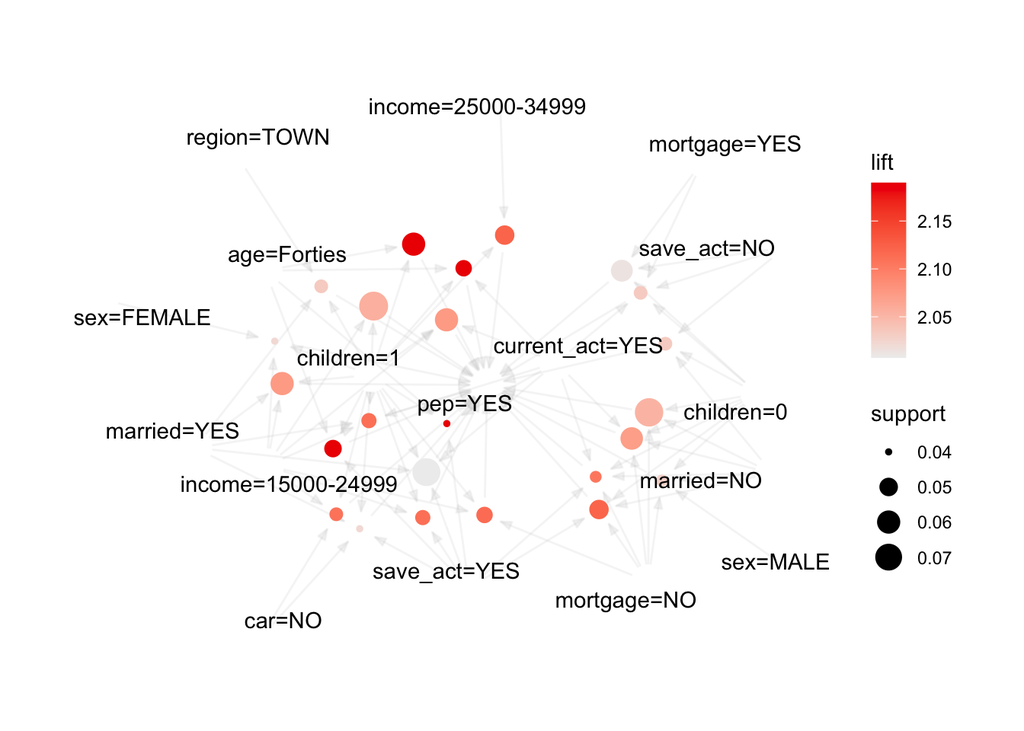

```r
plot(bankRulesPEP, method = "graph")
```

This plot provides a nice visualization of all the customer characteristics that are involved in the set of rules targeting having a personal equity plan.

When determining which five rules to highlight as the most interesting, the main focus was selecting rules that described unique customer profiles where one or more of the left hand side items were unique to only one rule out of the five. This will create a wide variety of profiles so multiple demographics can be targeted with advertisements.

The five most interesting rules are as follows:

1. {age=Forties, children=1, save_act=YES, current_act=YES} -> {pep=YES}

This rule has a support of 0.04, a confidence of 1, and a lift of 2.19. This rule describes a customer who is middle aged and has one child. They may or may not be married, but they have a history of activity with the bank as well as financial knowledge and responsibility. They may also be a small business owner since they have a current account. Based on their having a savings account, they may be doing well enough that they have extra money availble to invest in a PEP. The confidence value of 1 actually means that all existing customers with this profile have a PEP so potential new customers who share these characteristics would be excellent targets for the advertisements. This type of customer may be best targeted with a mailing/email advertisement as they are likely doing business with these methods of communication and will see the advertisement.

2. {married=NO, children=0, save_act=YES, mortage=NO} -> {pep=YES}

This rule has a support of 0.05, a confidence of 0.97, and a lift of 2.1. This rule describes a customer who is single and without many financial responsibilities. They do not have children to pay for and may be renting since they do not have a mortgage. Since they have a savings account it can be inferred that they have extra money and are very likely open to investing some of that extra money in a PEP. This type of customer may be most easily targeted with TV advertisements since they would not be spending their free time with a spouse or taking care of children.

3. {region=TOWN, married=YES, children=1} -> {pep=YES}

This rule has a support of 0.04, a confidence of 0.93, and a lift of 2.03. This rule describes a customer who has a small immediate family and has enough money to be living outside of the city in the town region. Even though it is not mentioned in the rule, there is reason to believe they may own their own home and commute to work. They seem to be fairly well off and likely have money available for investments. Since it is so common for families living in a town region to commute into the city for work, this type of customer could be targeted by billboard advertisements.

4. {sex=MALE, married=NO, children=0, mortgage=NO} -> {pep=YES}

This rule has a support of 0.04, a confidence of 0.93, and a lift of 2.03. This rule describes an unmarried man without family responsibilities. They may be focused on their careers and making money. Since an investment is an opportunity to make more money, they are likely interested in turning their extra funds into additional profits. They do not currently have other financial responsibilities holding them back from making investments. This type of customer is likely to be reached through email or TV advertisements. Many unmarried men are at least somewhat “plugged in” spending time on the TV or computer.

5. {married=YES, children=1, car=NO, save_act=YES} -> {pep=YES}

This rule has a support of 0.04, a confidence of 0.92, and a lift of 2.02. This rule describes someone who has a small immediate family and does not need a car to commute to work or run errands. Even though this is not in the rule, a likely conclusion is that this type of person lives close enough to a city that public transportation is prevalent enough to eliminate the need for a car. They may also be within walking distance of necessities like those found at a grocery store. They also have enough money to have a savings account so they are likely open to using their excess money to open a personal equity plan. This type of customer could be reached though advertisements on public transportation like on those on the insides of buses or trains, or in railway stations.

## Conclusions

When advertising a product it is very important that the advertisement reaches the appropriate audience. If an advertising campaign is only seen by people who are uninterested or if it is administered in too broad of a scope, the money spent on marketing costs will likely not be recuperated from the product’s sales. However, if it is possible to ensure that the advertisement will be seen mostly by individuals who would be interested in the product, then potential profits can be maximized while minimizing marketing costs.

Personal equity plans are not for everyone. They require a person to have additional income that extends past their bills and require a willingness to take on the risk of making an investment. The main customer profiles that will be interested in personal equity plans are those with small immediate families who have some history of having multiple accounts with the bank, and unmarried customers, especially men, who do not have children or many financial responsibilities. Overall, the best form of advertisements, given this combination of profiles, would be TV advertisements, email campaigns, and roadside billboards. All of the customer profiles have reasons to see TV ads, whether it is because they themselves are watching TV or because they are spending time with their child while they are watching. They would see email advertisements because they are already to receiving financial information that way or because they are using email regularly to facilitate their personal business dealings. Also, many would see billboard advertisements as they commute to work, bring their child to school, or go out to meet people, as would be the case for those who are unmarried.

The process outlined in this report does not have to be a one time investigation. As targeted advertisements bring in more customers, those customers and all of their demographic and account information will be added to the customer database. As the number of samples of different customer profiles increases, new rules may be uncovered and existing rules may be strengthened or weakened. By regularly performing the association rule mining algorithms on continually expanding data sets, the targeted advertisements do not have to follow stagnant recommendations. One year the best form of advertisement may be through email campaigns, and the next year TV ads might work best. The true advantage of using data mining techniques, such as association rule mining, is the ability it gives a company to be flexible, making informed changes to their processes while allocating resources as efficiently as possible.